fossil

# Five PPI corpora, dug back up.

Co-occurrence and the corpus statistics came back exactly where the corpora survive. A rebuilt RelEx lands up to 7 F points from the paper’s, and the main claim holds.

See the tables

## Fig. 1

RelEx and co-occurrence F-scores for the five corpora.

Partly agreesRerun with a rebuilt RelEx

Published

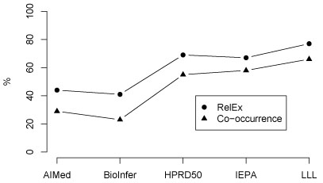

Our run

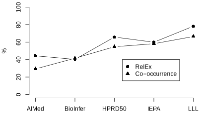

**Pixel size**

407 × 231

**Mean |Δ| grey**

6.414

**Pixels within ±24**

94.18%

**Ink distance (chamfer)**

1.476 px

**Best global shift**

0, 0 px

## Fig. 2

RelEx and co-occurrence F-scores on the filtered corpora (only entities that take part in an interaction kept); the unfiltered results of Fig. 1 in grey.

Partly agreesRerun with a rebuilt RelEx

Published

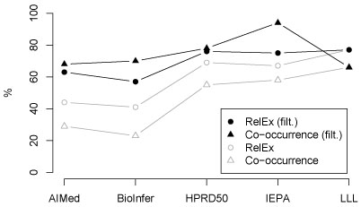

Our run

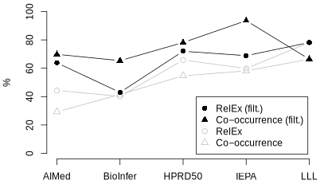

**Pixel size**

402 × 231

**Mean |Δ| grey**

7.075

**Pixels within ±24**

93.27%

**Ink distance (chamfer)**

1.268 px

**Best global shift**

0, 0 px

## Tables 2 to 4

Each cell is published / ours, rounded as printed; ≠ marks a difference at that precision. HPRD50, IEPA and LLL are the corpora whose surviving copies match the paper’s.

Partly agreesRerun on the surviving corpora

Table 2. PPI extraction performance (published / ours)

| Corpus | Co-occ. P | Co-occ. R | Co-occ. F | RelEx P | RelEx R | RelEx F |
| --- | --- | --- | --- | --- | --- | --- |
| AIMed | 0.17 / **0.17** | 0.95 / **1.00** ≠ | 0.29 / **0.29** | 0.40 / **0.40** | 0.50 / **0.50** | 0.44 / **0.44** |
| BioInfer | 0.13 / **0.26** ≠ | 0.99 / **1.00** ≠ | 0.23 / **0.42** ≠ | 0.39 / **0.59** ≠ | 0.45 / **0.30** ≠ | 0.41 / **0.40** ≠ |
| HPRD50 | 0.38 / **0.38** | 1.0 / **1.0** | 0.55 / **0.55** | 0.76 / **0.72** ≠ | 0.64 / **0.61** ≠ | 0.69 / **0.66** ≠ |
| IEPA | 0.41 / **0.41** | 1.0 / **1.0** | 0.58 / **0.58** | 0.74 / **0.70** ≠ | 0.61 / **0.53** ≠ | 0.67 / **0.60** ≠ |
| LLL | 0.50 / **0.50** | 1.0 / **1.0** | 0.66 / **0.66** | 0.82 / **0.93** ≠ | 0.72 / **0.68** ≠ | 0.77 / **0.78** ≠ |

Table 3. Per-sentence averages and fractions of sentences (published / ours)

| Corpus | Tokens | Entities | Entity pairs | Interactions | No entities | No interactions |
| --- | --- | --- | --- | --- | --- | --- |
| AIMed | 25.2 / **25.2** | 2.2 / **2.2** | 3.0 / **3.0** | 0.5 / **0.5** | 0.18 / **0.18** | 0.69 / **0.71** ≠ |
| BioInfer | 31.3 / **31.3** | 4.2 / **4.0** ≠ | 9.4 / **8.8** ≠ | 1.3 / **2.3** ≠ | 0.00 / **0.00** | 0.48 / **0.29** ≠ |
| HPRD50 | 26.1 / **26.1** | 2.8 / **2.8** | 3.0 / **3.0** | 1.1 / **1.1** | 0.00 / **0.00** | 0.38 / **0.38** |
| IEPA | 32.2 / **32.2** | 2.3 / **2.3** | 1.7 / **1.7** | 0.7 / **0.7** | 0.00 / **0.00** | 0.37 / **0.37** |
| LLL | 29.6 / **29.6** | 3.1 / **3.1** | 4.3 / **4.3** | 2.1 / **2.1** | 0.00 / **0.00** | 0.00 / **0.00** |

Table 4. Performance on the filtered corpora (published / ours)

| Corpus | Co-occ. P | Co-occ. F | RelEx P | RelEx F |
| --- | --- | --- | --- | --- |
| AIMed | 0.53 / **0.54** ≠ | 0.68 / **0.70** ≠ | 0.85 / **0.89** ≠ | 0.63 / **0.64** ≠ |
| BioInfer | 0.53 / **0.49** ≠ | 0.70 / **0.65** ≠ | 0.78 / **0.73** ≠ | 0.57 / **0.43** ≠ |
| HPRD50 | 0.64 / **0.64** | 0.78 / **0.78** | 0.93 / **0.88** ≠ | 0.76 / **0.72** ≠ |
| IEPA | 0.88 / **0.88** | 0.94 / **0.94** | 1.00 / **1.00** | 0.75 / **0.69** ≠ |
| LLL | 0.50 / **0.50** | 0.66 / **0.66** | 0.82 / **0.93** ≠ | 0.77 / **0.78** ≠ |

| Agreement at the printed precision | All five corpora | HPRD50, IEPA, LLL |
| --- | --- | --- |
| Table 2, co-occurrence | 11 of 15 | 9 of 9 |
| Table 2, RelEx | 3 of 15 | 0 of 9 |
| Table 3 | 25 of 30 | 18 of 18 |
| Table 4, co-occurrence | 6 of 10 | 6 of 6 |
| Table 4, RelEx | 1 of 10 | 1 of 6 |

Co-occurrence and the corpus statistics are arithmetic on the annotation, so where the corpus is the paper’s they come back exactly. AIMed’s surviving copy lacks 12 sentences and its self-interactions (about 5% of AIMed’s interactions in the paper), so its co-occurrence recall is 1.00, not 0.95. RelEx was never released; ours is rebuilt from the two papers’ descriptions. Its F is within 7 points of the paper’s on the three matching corpora, but it matches 0 of 9 of their RelEx cells.

## The claims in the text

The paper’s summary numbers. **Ours** is our run: it is the reproduction, and the verdict reads only that column. **Paper’s tables** runs the same code on the paper’s own Tables 2 and 4; it returns the paper’s text, which shows we compute each number the way the paper did, not that our run agrees. **Paper’s BioInfer row** is our run with BioInfer’s numbers replaced by the paper’s: it shows how much BioInfer matters, and moves toward the paper by construction.

Partly agrees3 of 8 hold, 1 close, 4 differ

| Claim | Paper | Ours | Verdict | Paper’s tables | Paper’s BioInfer row |
| --- | --- | --- | --- | --- | --- |
| RelEx varies more between corpora than between the methods | 19 vs 13 points | **19.5 vs 8.2 points** | holds | 19.4 vs 13.4 points | 19.2 vs 11.5 points |
| Co-occurrence beats RelEx on every filtered corpus except LLL | yes | **yes** | holds | yes | yes |
| Kendall p, sentences without interactions against RelEx F | not significant | **0.817** | holds | 0.233 | 0.233 |
| Gap between the methods | 13 points | **8.2 points** | differs | 13.4 points | 11.5 points |
| Between-corpus RelEx difference after filtering | 11 points | **15.7 points** | differs | 10.6 points | 10.1 points |
| Smallest relative cut in F error, co-occurrence to RelEx | 21% | **−2.3%** | differs | 21.1% | 4.1% |
| Largest relative cut in F error | 32% | **35.0%** | close | 32.4% | 35.0% |
| Kendall p, interactions per entity pair against RelEx F | about 0.08 | **0.233** | differs | 0.083 | 0.083 |

A yes/no claim holds if it is true in our run, and “not significant” holds if p ≥ 0.05. A number holds if it rounds to the paper’s value, is close if within 10% of it, and differs otherwise.

Per corpus: relative cut in F error from co-occurrence to RelEx, and RelEx F

| Corpus | Our copy of the corpus | Error cut, paper’s tables | Ours | RelEx F, paper | Ours |
| --- | --- | --- | --- | --- | --- |
| AIMed | 12 sentences and self-interactions missing | 21.1% | **21.2%** | 0.44 | **0.44** |
| BioInfer | later conversion | 23.4% | **−2.3%** | 0.41 | **0.40** |
| HPRD50 | the paper’s | 31.1% | **24.5%** | 0.69 | **0.66** |
| IEPA | the paper’s | 21.4% | **4.1%** | 0.67 | **0.60** |
| LLL | the paper’s | 32.4% | **35.0%** | 0.77 | **0.78** |

The main claim holds: in our run RelEx’s F varies by 19.5 points between corpora, more than the 8.2-point gap between the methods. The numbers that differ have two causes. BioInfer’s surviving copy is a later conversion, and it sets our smallest error cut (−2.3%, BioInfer). Our rebuild of RelEx is the other cause: on HPRD50, IEPA and LLL, whose corpora are the paper’s, it matches 0 of 9 of the paper’s RelEx cells in Table 2. On IEPA, co-occurrence F is the paper’s 0.58, but RelEx F is 0.60 against 0.67. So even with the paper’s BioInfer row the smallest error cut is 4.1% (IEPA) against 21%, and the gap between the methods is 11.5 points against 13. With the paper’s BioInfer row, the filtered difference (10.1 points) and the Kendall p (0.083) come near the paper’s, but that column takes one corpus from the paper; our run gives 15.7 points and 0.233.

**Result:** the main finding of the paper holds. Some summary values do not agree. Two causes explain these differences: the only surviving copy of BioInfer is a later conversion, and RelEx, which the authors did not release, had to be rebuilt.

## What came back

**The corpora**

The unified XML of all five corpora survives only in a third-party GitHub copy (metalrt/ppi-dataset, commit dd49ea3). HPRD50, IEPA and LLL match the paper; AIMed has 1943 of 1,955 sentences; BioInfer is the later, improved binarization with 2,534 interactions.

**The tokenizer**

MedPost’s tokens give Table 3’s token counts exactly on all five corpora, so the paper counted MedPost tokens.

**Stanford Parser 1.5.1**

The 2006 release the paper names is still on Stanford’s download server and runs on Java 11. Every sentence parses.

**RelEx’s relation terms**

Fundel et al.’s supplementary list, recovered from a 2014 Wayback capture of their page: 175 stems, which expand to the 1,048 terms their paper reports.

**RelEx**

Rules 1 to 3, enumeration expansion, the negation filter and the term filter, rebuilt in Python on the 1.5.1 dependencies. Developed on HPRD50 only, then run once on all corpora.

**MedPost on 64-bit**

The 2008 source counts its abbreviation table in bytes, not entries, and crashes on x86_64. One line fixes it.

## What stayed buried

- The paper’s BioInfer conversion (Causal-Change interactions only). The archived download page still links it, but the file itself was never archived
- The conversion programs at mars.cs.utu.fi/PPICorpora
- The authors’ RelEx code, and the details of its chunking and negation list
- The 250 interactions behind Fig. 3 and Table 5, and their manual labels. Fig. 4 is an illustration

Co-occurrence and the corpus statistics come back exactly where the corpus survives. RelEx, rebuilt, comes back up to 7 F points from the paper’s. The main claim holds; 4 of the 8 claims in the text differ in our run.

## What we matched

Figs 1 and 2 are base R plots. We draw them with base R on the published pixel grid: the plot region comes from the tick marks of the published axes, so a data point lands where the paper’s would. Only the text size, symbol size and legend spacing are fitted, on a render of the published values.

**Our run**

The five unified corpora from the only surviving copy, MedPost for tokens and tags, Stanford Parser 1.5.1 (the version the paper names) for dependencies, and our reimplementation of RelEx with Fundel et al.’s own 1,048 relation terms.

**Axes**

One linear map per axis from the tick marks (x = 1 to 5, y = 0 to 100), plus R’s 4% axis extension and half a pixel for the pixel centre.

**Fitted, not data**

Point size 12 (R’s default), default label distances, symbol size 1.2, legend symbol spacing 1.3 to 1.4. Fitted on a render of the paper’s own Table 2 and 4 values.

## The session

Session not recorded: no log of the agent session was kept for this reproduction.